# Series

## 绘图参数表

```
pandas绘图的速查表
data : Series or DataFrame
    df.plot(x,y)和 s.plot()

x :如不指定默认是行索引

y : "a"或者["a,"b"]
kind : str


        df.plot.line() # 折线的全写方式
        df.plot.bar() # 柱状图
        df.plot.barh() # 横向柱状图 （条形图）
        df.plot.hist() # 直方图
        df.plot.box() # 箱形图
        df.plot.kde() # 核密度估计图
        df.plot.density() # 同 df.plot.kde()
        df.plot.area() # 面积图
        df.plot.pie() # 饼图
        df.plot.scatter() # 散点图
        df.plot.hexbin() # 六边形箱体图，或简称六边形图

subplots : bool, default False ,#将图例分开来显示


figsize : a tuple (width, height) in inches
    Size of a figure object.  #图形的大小
use_index : bool, default True
    Use index as ticks for x axis.#默认以行索引作为x轴

title : str or list #标题

grid : bool, default None (matlab style default)
    Axis grid lines. #网格线

legend : bool or {'reverse'}
    Place legend on axis subplots.#是否显示图例

style : list or dict # 样式:颜色.线条,线状
    The matplotlib line style per column.



xticks : sequence #x轴刻度
    Values to use for the xticks.
yticks : sequence #y轴刻度
    Values to use for the yticks.
xlim : 2-tuple/list #x范围
    Set the x limits of the current axes.
ylim : 2-tuple/list
    Set the y limits of the current axes.

xlabel : # x标签
ylabel :

rot : int, default None
    Rotation for ticks (xticks for vertical, yticks for horizontal
    plots).
fontsize : int, default None
    Font size for xticks and yticks.

colormap : str or matplotlib colormap object, default None
    Colormap to select colors from. If string, load colormap with that
    name from matplotlib.
colorbar : bool, optional
         If True, plot colorbar (only relevant for 'scatter' and 'hexbin'
    plots).

stacked=True 堆积
```

## 折线图

**折线图（Line Chart）折线图是用线条段将各数据点连接起来而组成的图形，它能表达一个数据的走势，一般和时间相关**

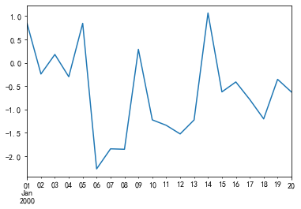

```python
ts.plot.line()# 写法 ts.plot(kind="line")
# 1.
# 可以指定 x 轴和 y 轴：

# df[:5].plot(x='name', y='Q1')
# df[:5].plot('name', ['Q1', 'Q2']) # 指定多条
```

```python
df1.head(200)
```

|  | city | companyFullName | companyId | companyLabelList | companyShortName | companySize | businessZones | firstType | secondType | education | industryField | positionId | positionAdvantage | positionName | positionLables | salary | workYear |
| --- | --- | --- | --- | --- | --- | --- | --- | --- | --- | --- | --- | --- | --- | --- | --- | --- | --- |
| 0 | 上海 | 纽海信息技术(上海)有限公司 | 8581 | ['技能培训', '节日礼物', '带薪年假', '岗位晋升'] | 1号店 | 2000人以上 | ['张江'] | 技术 | 数据开发 | 硕士 | 移动互联网 | 2537336 | 知名平台 | 数据分析师 | ['分析师', '数据分析', '数据挖掘', '数据'] | 7k-9k | 应届毕业生 |
| 1 | 上海 | 上海点荣金融信息服务有限责任公司 | 23177 | ['节日礼物', '带薪年假', '岗位晋升', '扁平管理'] | 点融网 | 500-2000人 | ['五里桥', '打浦桥', '制造局路'] | 技术 | 数据开发 | 本科 | 金融 | 2427485 | 挑战机会,团队好,与大牛合作,工作环境好 | 数据分析师-CR2017-SH2909 | ['分析师', '数据分析', '数据挖掘', '数据'] | 10k-15k | 应届毕业生 |
| 2 | 上海 | 上海晶樵网络信息技术有限公司 | 57561 | ['技能培训', '绩效奖金', '岗位晋升', '管理规范'] | SPD | 50-150人 | ['打浦桥'] | 设计 | 数据分析 | 本科 | 移动互联网 | 2511252 | 时间自由,领导nic | 数据分析师 | ['分析师', '数据分析', '数据'] | 4k-6k | 应届毕业生 |
| 3 | 上海 | 杭州数云信息技术有限公司上海分公司 | 7502 | ['绩效奖金', '股票期权', '五险一金', '通讯津贴'] | 数云 | 150-500人 | ['龙华', '上海体育场', '万体馆'] | 市场与销售 | 数据分析 | 本科 | 企业服务,数据服务 | 2427530 | 五险一金 绩效奖金 带薪年假 节日福利 | 大数据业务分析师【数云校招】 | ['商业', '分析师', '大数据', '数据'] | 6k-8k | 应届毕业生 |
| 4 | 上海 | 上海银基富力信息技术有限公司 | 130876 | ['年底双薪', '通讯津贴', '定期体检', '绩效奖金'] | 银基富力 | 15-50人 | ['上海影城', '新华路', '虹桥'] | 技术 | 软件开发 | 本科 | 其他 | 2245819 | 在大牛下指导 | BI开发/数据分析师 | ['分析师', '数据分析', '数据', 'BI'] | 2k-3k | 应届毕业生 |
| ... | ... | ... | ... | ... | ... | ... | ... | ... | ... | ... | ... | ... | ... | ... | ... | ... | ... |
| 195 | 上海 | 上海誉狼资产管理有限公司 | 157236 | NaN | 上海誉狼 | 150-500人 | ['陆家嘴'] | 金融类 | 天使投资/VC/PE | 不限 | 金融,移动互联网 | 2571792 | 五险一金，做五休二、晋升空间大、福利待遇 | 直播室分析师 | ['投资', '分析师'] | 6K-8K | 1年以下 |
| 196 | 上海 | 上海青之桐投资管理有限公司 | 28095 | ['美女多', '出国旅游', '不打卡', '带薪年假'] | 青桐资本 | 50-150人 | NaN | 技术 | 软件开发 | 本科 | 金融 | 2446466 | 互联网投行 精英团队 气氛轻松 福利丰厚 | BI数据分析师 | ['分析师', '数据分析', '数据', 'BI'] | 10k-20k | 1-3年 |
| 197 | 上海 | 上海锐战网络科技有限公司 | 7158 | ['年终分红', '绩效奖金', '专项奖金', '年底双薪'] | 傲世堂 | 150-500人 | NaN | 技术 | 后端开发 | 本科 | 游戏 | 2478371 | 优秀团队,免费班车,弹性工作制,早餐下午茶 | 数据平台开发工程师 | ['平台', '数据'] | 8k-16k | 1年以下 |
| 198 | 上海 | 东方财富信息股份有限公司 | 35179 | ['技能培训', '节日礼物', '股票期权', '绩效奖金'] | 东方财富 | 2000人以上 | ['龙华', '上海体育场', '万体馆'] | 设计 | 数据分析 | 本科 | 金融 | 1532050 | 发展空间 年底双薪 五险一金等 | 数据分析师（天天基金） | ['分析师', '数据分析', '数据'] | 6k-12k | 1-3年 |
| 199 | 上海 | 拉扎斯网络科技（上海）有限公司 | 51480 | ['节日礼物', '绩效奖金', '年度旅游', '岗位晋升'] | 饿了么 | 2000人以上 | ['长征', '金沙江路', '梅川路'] | 设计 | 用户研究/需求分析 | 本科 | 移动互联网 | 2514041 | 领导授权+晋升+工作挑战 | 商业分析师 | ['分析师', '用户研究', 'BI'] | 10k-20k | 1-3年 |

200 rows × 17 columns

## 柱状图

**柱状图（bar chart），使用与轴垂直的柱子，**  
**通过柱形的高低来表达数据的多少，适用于数据的对比，在整体中也能看到数据的发展变化趋势**

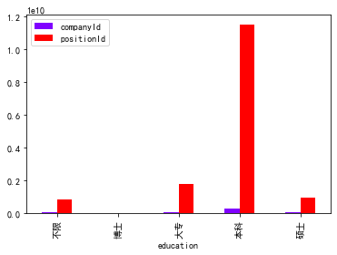

```python
df1.groupby("education")["companyId","positionId"].sum().plot.bar(colormap='rainbow')#colormap='rainbow' 默认配色
```

```
# 画图的写法讲究
#  1.  df.loc[:10] # 取部分
#     .set_index('name') # 设为索引 ,此时的x就可以默认为行索引了
#     .plot() # 折线图

#  2. 可以指定 x 轴和 y 轴：

# df[:5].plot(x='name', y='Q1')
# df[:5].plot('name', ['Q1', 'Q2']) # 指定多条
```

```python
df = pd.DataFrame(3 * np.random.rand(4, 2),
                  index=['a', 'b', 'c', 'd'],
                  columns=['x', 'y'])
```

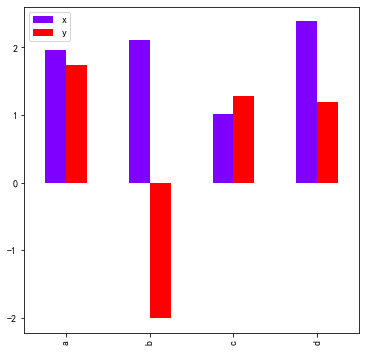

```python
# df.loc[:6] # 取部分
#     .set_index('name') # 设为索引
#     .plot
#     .bar() # 柱状图
#数据有负值的情况
df.iloc[1,1]=-2
df.plot.bar(figsize=(6, 6),colormap='rainbow')
```

[output not shown]

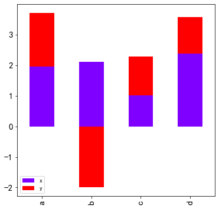

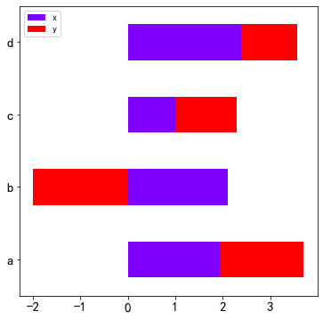

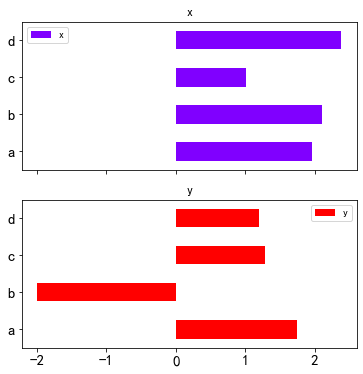

```python
# 堆叠

# 可以将同一索引的多个数据堆叠起来：

df.plot .bar(stacked=True,figsize=(6, 6),colormap='rainbow',fontsize=15) # 柱状图, 堆叠

df.plot .barh(stacked=True,figsize=(6, 6),colormap='rainbow',fontsize=15) # 条形图, 堆叠

df.plot .barh(stacked=True,figsize=(6, 6),colormap='rainbow',fontsize=15,subplots=True) # 条形图, 堆叠,也支持子图
```

## 饼图

**如果您的数据包含任何 NaN，它们将自动填充 0**  
*如果您的数据中有任何负值，则会引发 ValueError*

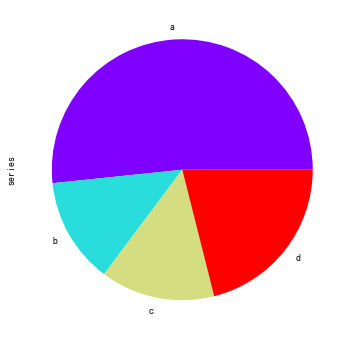

```python
s = pd.Series(3 * np.random.rand(4),
              index=['a', 'b', 'c', 'd'], name='series')
s.plot.pie(figsize=(6, 6),colormap='rainbow')#需要两个参数
```

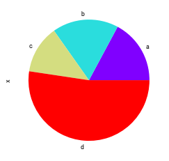

```python
df = pd.DataFrame(3 * np.random.rand(4, 2),
                  index=['a', 'b', 'c', 'd'],
                  columns=['x', 'y'])

df.plot.pie(y='x',colormap='rainbow',legend=False)
```

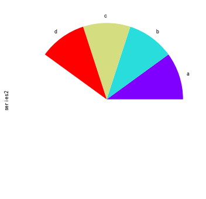

```python
#如果传递的总和小于 1.0，则 matplotlib 将绘制一个扇形。

series = pd.Series([0.1] * 4,
                   index=['a', 'b', 'c', 'd'],
                   name='series2')
series.plot.pie(figsize=(6, 6),colormap='rainbow',legend=False)
```

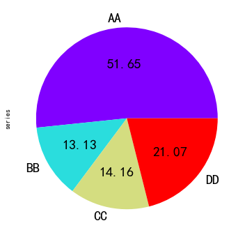

```python
s.plot.pie(labels=['AA', 'BB', 'CC', 'DD'], # 标签，指定项目名称
           #colors=['r', 'g', 'b', 'c'], # 指定颜色
           autopct='%.2f', # 数字格式
           fontsize=20, # 字体大小
           figsize=(6, 6), # 图大小
           colormap='rainbow',
           legend=False)
```

## 直方图

**直方图(Histogram)，又称质量分布图，是一种统计报告图，**  
**由一系列高度不等的纵向条纹或线段表示数据分布的情况。**  
**一般用横轴表示数据类型，纵轴表示分布情况。**

**直方图的意义**  
**直方图描述的是数据在不同区间内的分布情况，描述的数据量一般比较大，图示如下：**

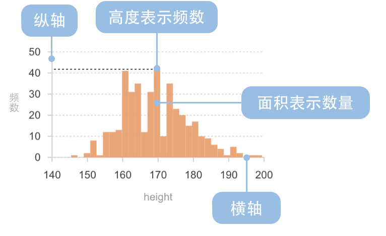

```python
df = pd.DataFrame({'a': np.random.randn(1000) + 1,
                   'b': np.random.randn(1000),
                   'c': np.random.randn(1000) - 1},
                  columns=['a', 'b', 'c'])
df.head()
```

|  | a | b | c |
| --- | --- | --- | --- |
| 0 | 0.410004 | 0.369387 | 0.400480 |
| 1 | 1.882546 | -0.761947 | -1.439130 |
| 2 | 2.814234 | 1.067023 | -1.257330 |
| 3 | 1.394800 | -1.180966 | -1.436005 |
| 4 | 1.272234 | 0.401689 | -1.921680 |

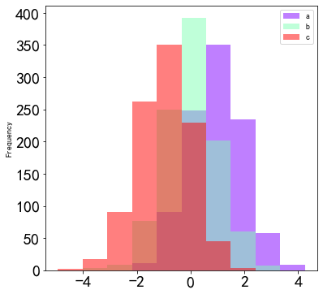

```python
df.plot.hist(alpha=0.5, fontsize=20, # 字体大小
           figsize=(6, 6), # 图大小
           colormap='rainbow')#alpha 透明度, bin=10(默认)分箱数
```

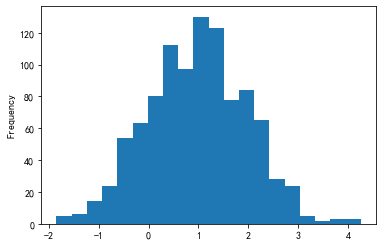

```python
df.a.plot.hist(bins=20)#一组数据
```

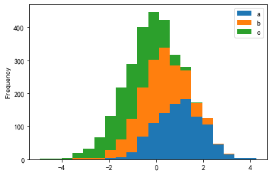

```python
#堆叠

#可以堆叠，并指定分箱数量：

df.plot.hist(stacked=True, bins=20)
```

[output not shown]

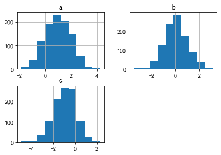

```python
df.hist()
```

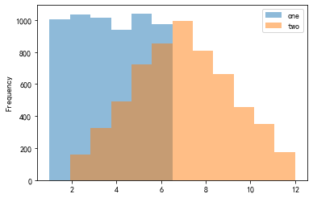

```python
# 例子

# 当我们绘制骰子6000次时，我们期望每个值大约获得1000次。 但是，当我们绘制两个骰子并将结果相加时，分布将完全不同。 直方图说明了这些分布：

df = pd.DataFrame(np.random.randint(1, 7, 6000),
                  columns = ['one'])
df['two'] = df['one'] + np.random.randint(1, 7, 6000)
df.plot.hist(bins=12, alpha=0.5)
```

## 箱型图

**箱形图（Box Chart）又称盒须图、盒式图或箱线图，是一种用作显示一组数据分布情况的统计图。**  
**Series.plot.box() 、 DataFrame.plot.box(), 和 DataFrame.boxplot() 都可以绘制箱形图。**

作用

从箱形图中我们可以观察到

- 组数据的关键值：中位数、最大值、最小值等。
- 数据集中是否存在异常值，以及异常值的具体数值。
- 数据是否是对称的。
- 这组数据的分布是否密集、集中。
- 数据是否扭曲，即是否有偏向性。

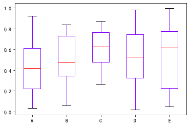

```python
df = pd.DataFrame(np.random.rand(10, 5),
                  columns=['A', 'B', 'C', 'D', 'E'])
df.plot.box( colormap='rainbow') # 所有列
```

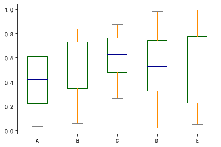

```python
# 配色

# 给图形中的一些元素指定颜色：

color = {'boxes': 'DarkGreen', # 箱体颜色
         'whiskers': 'DarkOrange', # 连线颜色
         'medians': 'DarkBlue', # 中位数颜色
         'caps': 'Gray'} # 极值颜色

df.plot.box(color=color, sym='r+')
```

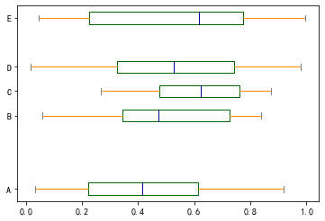

```python
#vert=False 将图形横向，positions 控制位置：

df.plot.box(vert=False, positions=[1, 4, 5, 6, 8],color=color, sym='r+')#横向箱图
```

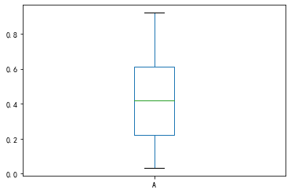

```python
df["A"].plot.box() # 单个列
```